# 8_2_Homework

3/3/2022

# Packages

```r
library(fpp3)
library(seasonal)
library(fma)
```

# 1. Derive the formula for a 3 x 7 Moving Average. Also indicate how you would implement that moving average using window functions in R.

- The method to obtain the formula is clarified in detail in the **video 7_1_MAs_of_MAs which is uploaded on blackboard.**
- **PERFORM THE FOLLOWING CHECK:** once you obtain the formula, check that the sum of the coefficients of the different time values of y adds up to 1. If it does not, the formula obtained is not correct.
- Remember **we want to obtain a SYMMETRIC moving average** (same amount of points to the right than to the left)

SOLUTION: see separate video deriving the formula.

# 2. Labour force in Australia - Decomposition

The series `labour` details the number of persons in civilian labour force in Australia, each month, from February 1978 to August 1995.

Bear in mind that you need to **install and load the library `fma`** for the series to be available

```
## Plot variable not specified, automatically selected `.vars = value`
```

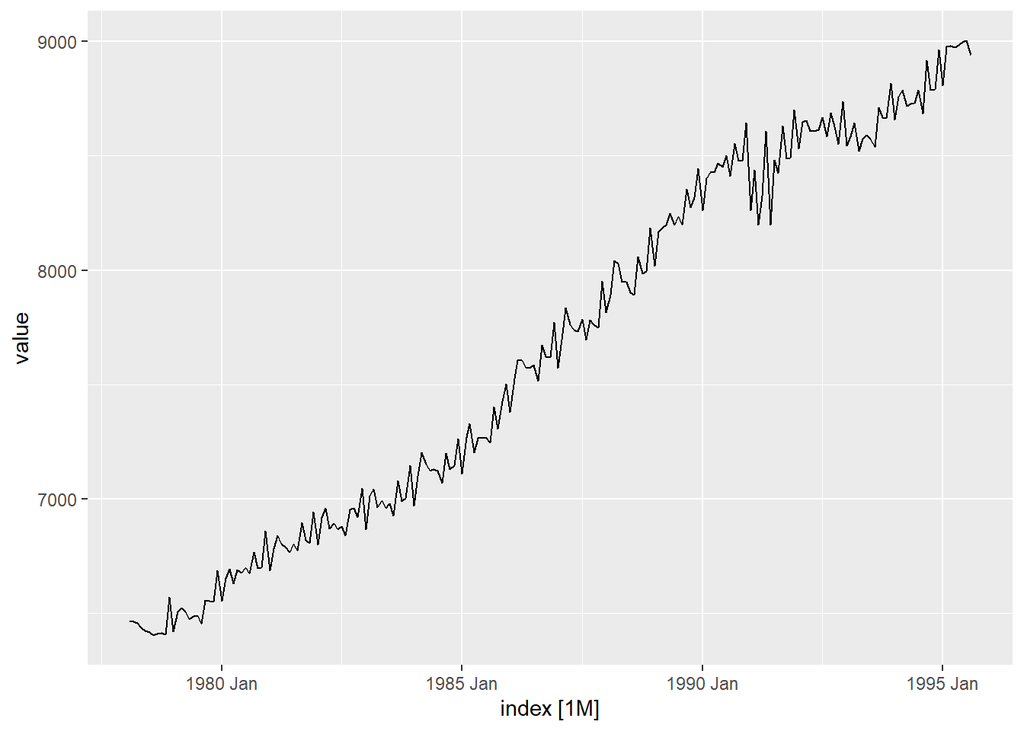

```r
labour_tsibble <-as_tsibble(labour)
autoplot(labour_tsibble)
```

## 2.1 Perform an STL decomposition of the data with the default values for the trend and seasonal window (that is, without specifying further paramenters.)

## 2.2 Take a look at the crisis around 1991-1992 and answer these questions:

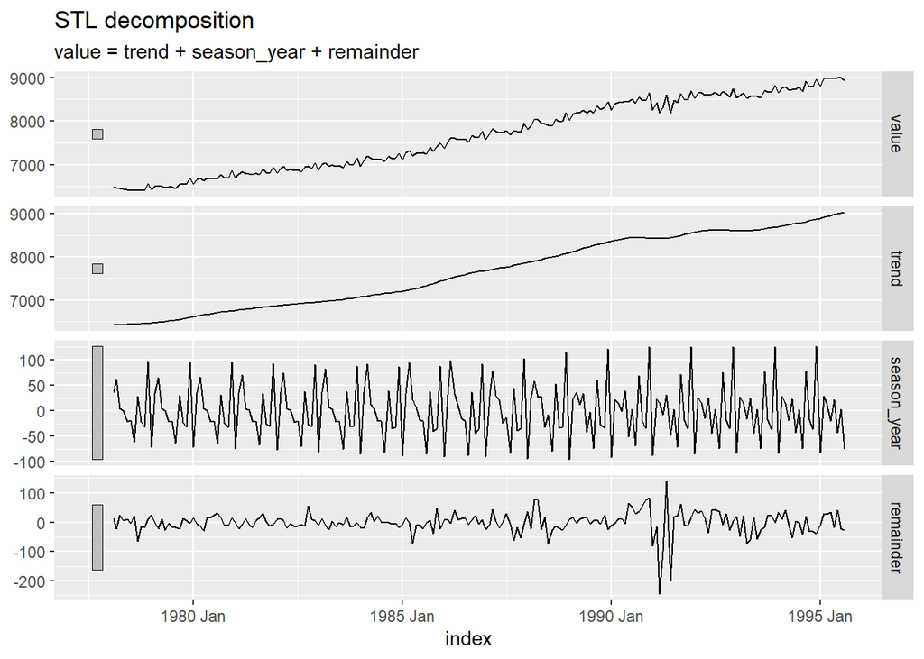

```r
stl_dcmp_1 <- labour_tsibble %>%
  model(stl = STL(value)) %>%
  components()

stl_dcmp_1 %>% autoplot()
```

- Does the trend adequately capture this crisis?

The trend does not adequately capture the crisis. The default averaging window used for the moving average in the STL function is too wide and the trend is relatively insensitive to these changes.

- What do you think of the time series components in the vicinity of this crisis?

The trend remains relatively insensitive to the crisis and the seasonal component does not react fast enough either. As a result most of the crisis is transferred to the remainder component.

- The grey bars printed on the left of the decomposition graphs when using autoplot are created to compare the scale between graphs (the length of the bar is the same on all graphs). Comparing the scale of the graphs, **do you think this is a good decomposition?** **why? why not?**

The decomposition does not seem sensitive, at least around the crisis of 91-92. There the fluctuations of the randim component are much greater than those of the seasonal component. This is clear if one compares the grey bars in both graphs.

- How would you **change the window parameters so that the trend captures better the 91-92 crisis?** Perform several attempts to improve the STL decomposition.

The goal is to have both the trend and the seasonal components capture the fluctuations associated to the crisis. For that purpose we can reduce the averaging windows of these two components (see code below).

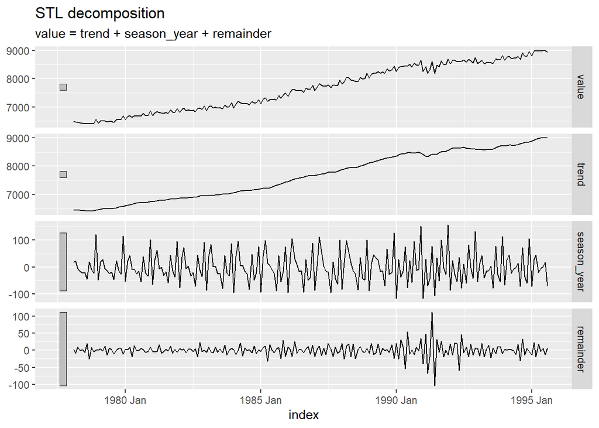

```r
# Reduction of the averaging windows to try to better capture the crisis at 91-92.
labour_tsibble %>%
  model(
    STL(value ~ trend(window = 5) + # Manually change this value from the default 13
                season(window = 5))
    ) %>%
  components() %>%
  autoplot()
```

After multiple attempts, we see that the crisis is still cascaded down to the remainder component to a great extent. In that region the remainder becomes at least of the same order than the seasonal component, if not greater.

In this particular case the decomposition would not bring much to our analysis in the vicinity of the crisis. Whatever model we created for this analysis would have to account fot this crisis. For example introducing macro regressors that related to the behavior of this macro variable in the crisis. Alternatively we could make a correction to the time series to exclude the crisis from our analysis.